# Effects of loan variables on APR, Loan Status, and Loan original amount.

## by Shikhar Sharma

## Investigation Overview

> My main objective was to analyze loan data and find the variables which affected the APR, loan status and loan original amount.

## Distribution of 'Borrower APR'

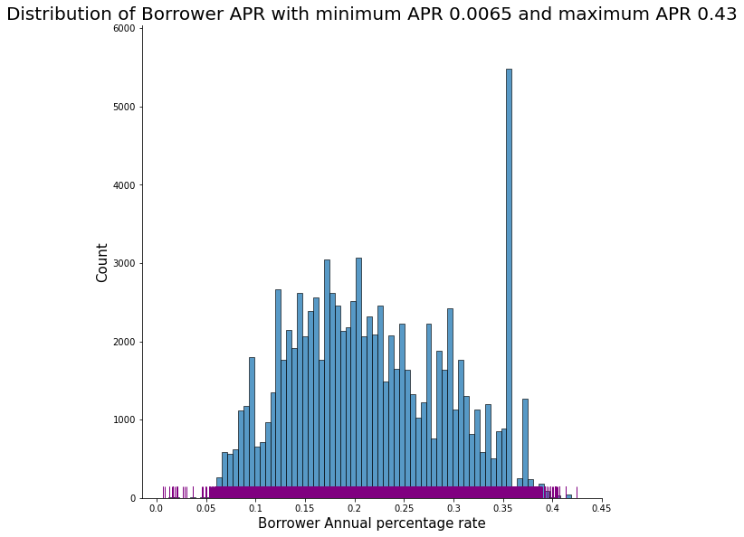

## Distribution of 'Term'

> Maximum borrowers have taken loan (72343) for 36 months term based on the data. Also, number of times loan taken for 60 months is 22555, and for 12 months, count is 1409 which is the lowest.

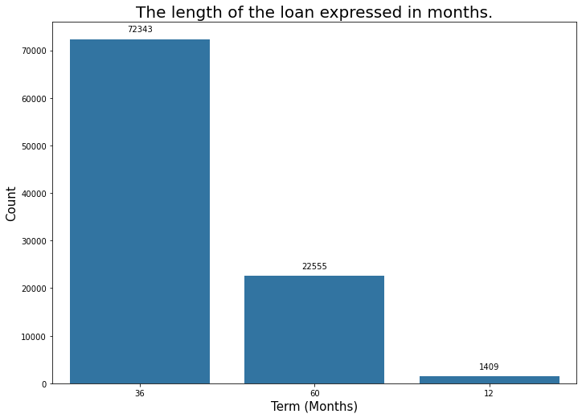

## Distribution of 'Borrower Rate'

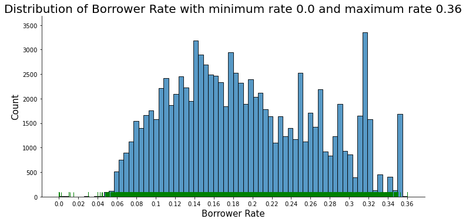

## Distribution of 'Debt To Income Ratio'

> In debt to income ratio, the distribution is right skewed and unimodal. Also, I did some transformation by increasing the bins in order to reduce the noise and make the plot more readable. We have maximum count of DTI between 0.15 and 0.20. Their is a gradual increase in the frequencies until the highest peak is reached (0.15-0.2). After that their gradual decrease in frequencies until the next peak is reached.

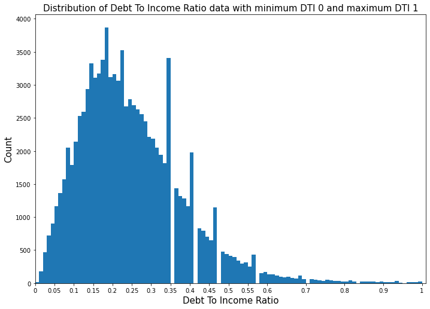

## Distribution of 'Loan original Amount'.

> The distribution of 'Loan original amount' is right skewed and unimodal. Also, maximum count of loan original amount is $4,000$ and density of data points is highest between $1000$ and $5000$. Also, minimum and maximum loan original amount are $1000$ and $35000$ respectively.

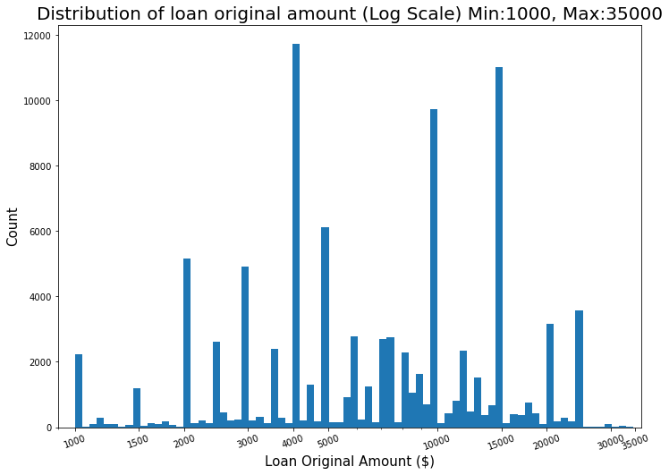

## Distribution of 'Credit Score Class'.

> Credit score class are assigned on the basis of credit score range lower and credit score range upper. Class 'Good' has the highest count whereas class 'Poor' has the lowest count.
> > - Exceptional: 800 to 850. FICO® Scores ranging from 800 to 850 are considered exceptional.
> > - Very good: 740 to 799. FICO® Scores in the 740 to 799 range are deemed very good.
> > - Good: 670 to 739. FICO® Scores in the range of 670 to 739 are rated good.
> > - Fair: 580 to 669.
> > - Poor: 300 to 579.

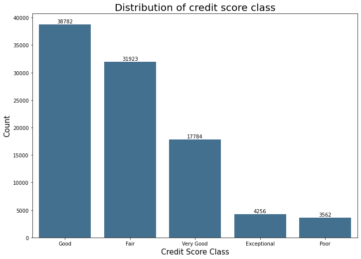

## Distribution of 'Loan Status'.

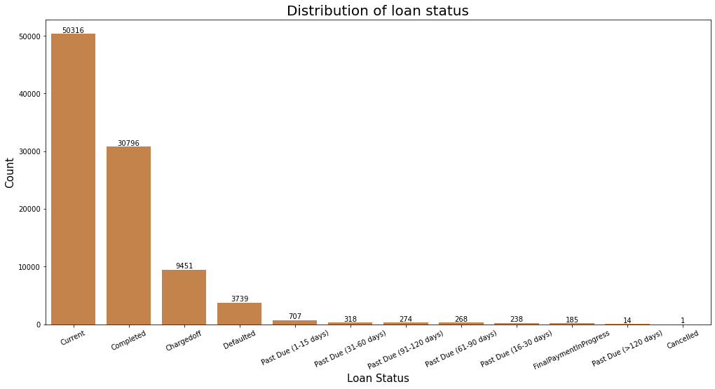

## Distribution of 'Listing Labels'.

> Plotting of listing labels shows that 'Debt consolidation' has the highest count. This could mean that many borrowers already have existing debts that is why they have taken debt consolidation loan in order to reduce the burden of existing debts and pay some amount for new loan every month at low interest.

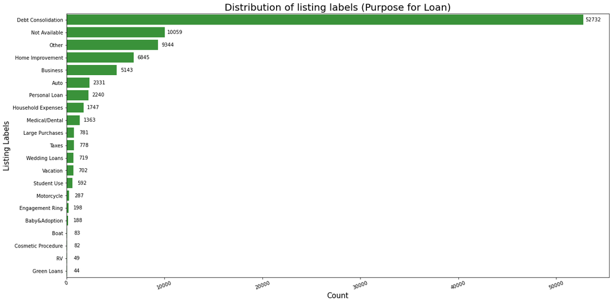

## Distribution of ' Stated Monthly Income'.

> Plotting of the 'Stated Monthly Income' using histogram shows that maximum number of borrowers have monthly income income between 2k and 10k with distribution being unimodal. The highest monthly income seems to be 4000 approx. Also, I did log transformation to make interpretations from the data more elucidated.

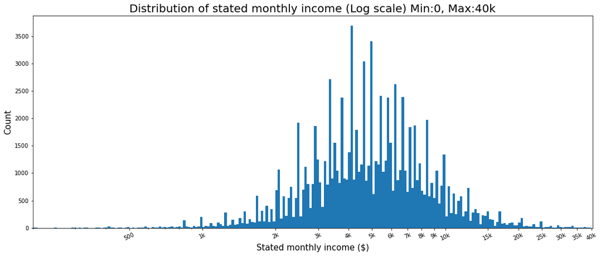

```
                                What features affect the Borrower APR?
```

## Borrower APR vs Borrower Rate

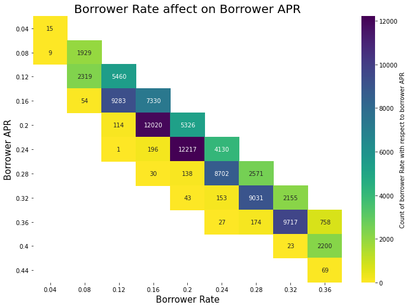

## Borrower APR vs Debt To Income Ratio (DTI).

> Their seems to exist a weak positive correlation which indicate that while both variables DTI and APR tend to go up in response to one another, the relationship is not very strong.

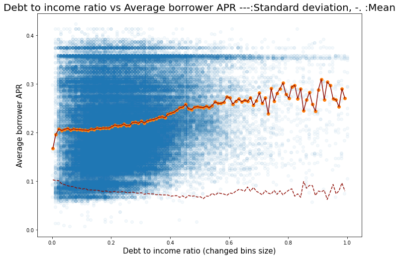

## Borrower APR vs Stated Monthly Income.

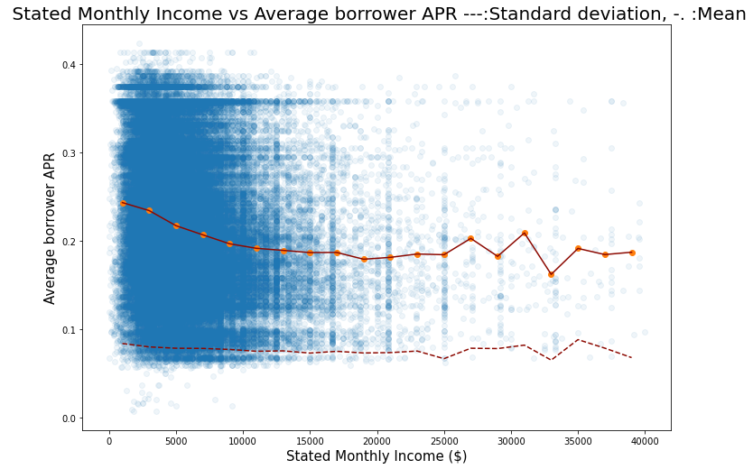

## Borrower APR vs Credit Score Class.

> Plotting of borrower APR with credit score class shows that count of APR's highest value is maximum for 'Poor' class and as we move from 'Poor' to 'Exceptional', count of APR's highest value decreases.  
> For 'Exceptional' maximum APR values are between 0.09 and 0.12 approx.. Thus, credit score class affects the borrower APR.

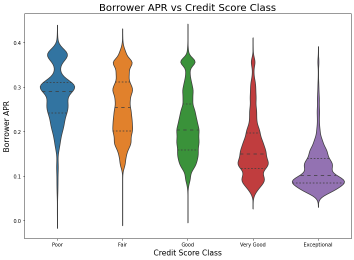

```
                                      What affects the loan status?
```

## Loan Status by Borrower APR and Credit Score Class.

> For credit score 'Exceptional' and 'Very Good', APR is below 0.20, and, for the rest, APR is above 0.20 in most cases. Also, if a borrower has credit score 'Exceptional' and loan status 'Completed', than he/she most likely to have a APR of 0.10 approx.. Moreover, we can see that in most of the cases if a borrower has credit score class 'Exceptional' or 'Very Good' or 'Good' or 'Fair' with APR in range 0.14-0.15 or 0.20-0.22 or 0.24-0.25 or 0.27-0.29 respectively, the loan status is going to be 'Past Due'. The large error bars indicate that data is very less.

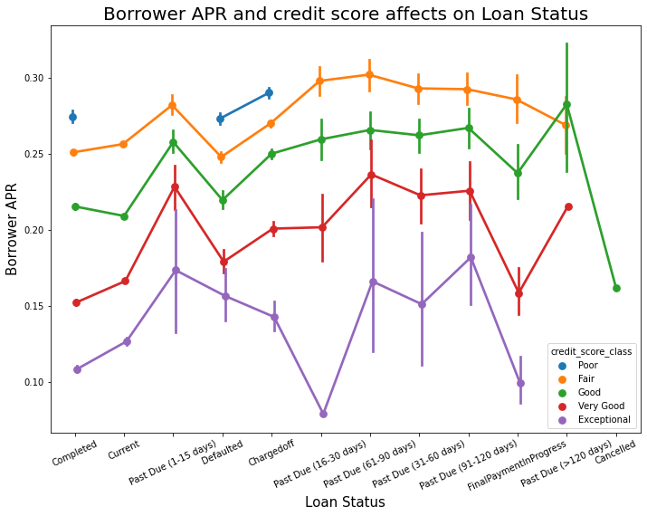

```
                                What affects the original loan amount?
```

## Loan original amount by EmploymentStatus and Credit score

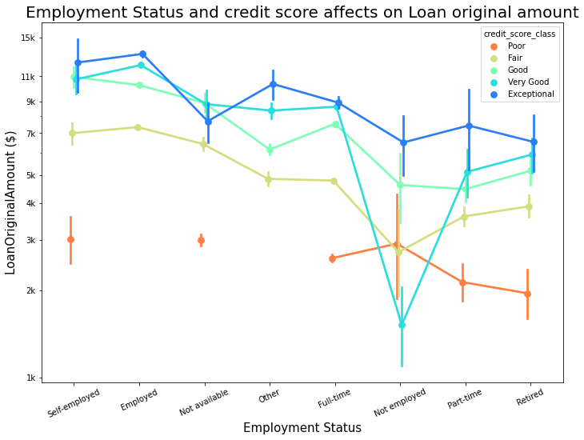

## Loan original amount by stated monthly income and credit score class.

> Many Borrowers with credit score of 'Exceptional','Very Good' and 'Good' tend to have high loan original amount compare to other credit class.

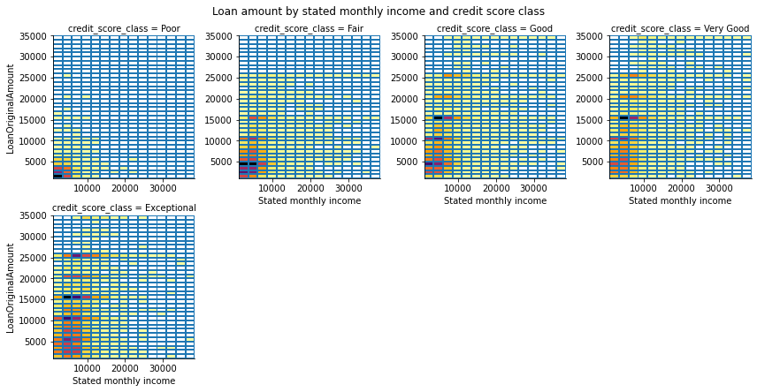